# Advanced Tree Models – Bagging, Random Forests, and Boosting

In this lab, we will cover some state-of-the-art techniques in the framework of tree models. We use the same datasets as in previous lab, Boston Housing data and Credit Scoring data.

```r
# load Boston data
library(MASS)
data(Boston)
index <- sample(nrow(Boston),nrow(Boston)*0.60)
boston.train <- Boston[index,]
boston.test <- Boston[-index,]

# load credit card data
credit.data <- read.csv("data/credit_default.csv", header=T)
# convert categorical variables
credit.data$SEX<- as.factor(credit.data$SEX)
credit.data$EDUCATION<- as.factor(credit.data$EDUCATION)
credit.data$MARRIAGE<- as.factor(credit.data$MARRIAGE)
# random splitting
index <- sample(nrow(credit.data),nrow(credit.data)*0.60)
credit.train = credit.data[index,]
credit.test = credit.data[-index,]
```

# 1 Bagging

*Bagging* stands for Bootstrap and Aggregating. It employs the idea of bootstrap but the purpose is not to study bias and standard errors of estimates. Instead, the goal of Bagging is to improve prediction accuracy. It fits a tree for each bootsrap sample, and then aggregate the predicted values from all these different trees. For more details, you may look at [Wikepedia](https://en.wikipedia.org/wiki/Bootstrap_aggregating), or you can find the original paper [Leo Breiman (1996)](https://link.springer.com/content/pdf/10.1007/BF00058655.pdf).

An available R package, `ipred`, provides functions to perform Bagging. You need to install this package if you didn’t do it before.

```r
library(ipred)
```

## 1.1 Bagging for regression tree.

Fit tree with bagging on Boston training data, and calculate MSE on testing sample.

```r
boston.bag<- bagging(medv~., data = boston.train, nbagg=100)
boston.bag
```

```
##
## Bagging regression trees with 100 bootstrap replications
##
## Call: bagging.data.frame(formula = medv ~ ., data = boston.train, nbagg = 100)
```

Prediction on testing sample.

```r
boston.bag.pred<- predict(boston.bag, newdata = boston.test)
mean((boston.test$medv-boston.bag.pred)^2)
```

```
## [1] 24.29658
```

Comparing with a single tree.

```r
library(rpart)
boston.tree<- rpart(medv~., data = boston.train)
boston.tree.pred<- predict(boston.tree, newdata = boston.test)
mean((boston.test$medv-boston.tree.pred)^2)
```

```
## [1] 30.62788
```

How many trees are good?

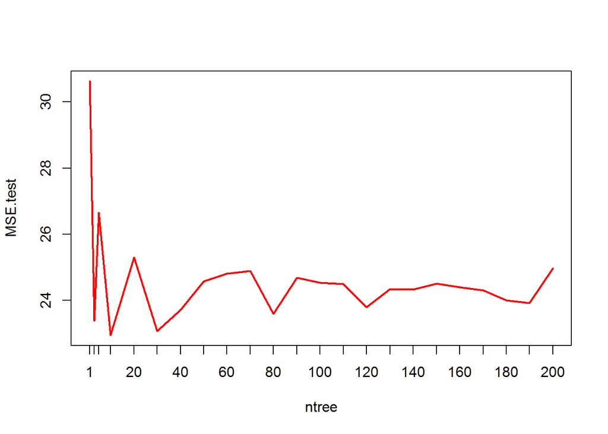

```r
ntree<- c(1, 3, 5, seq(10, 200, 10))
MSE.test<- rep(0, length(ntree))
for(i in 1:length(ntree)){
  boston.bag1<- bagging(medv~., data = boston.train, nbagg=ntree[i])
  boston.bag.pred1<- predict(boston.bag1, newdata = boston.test)
  MSE.test[i]<- mean((boston.test$medv-boston.bag.pred1)^2)
}
plot(ntree, MSE.test, type = 'l', col=2, lwd=2, xaxt="n")
axis(1, at = ntree, las=1)
```

By fitting the Bagging multiple times and predicting the testing sample, we can draw the following boxplot to show the variance of the prediction error at different number of trees.

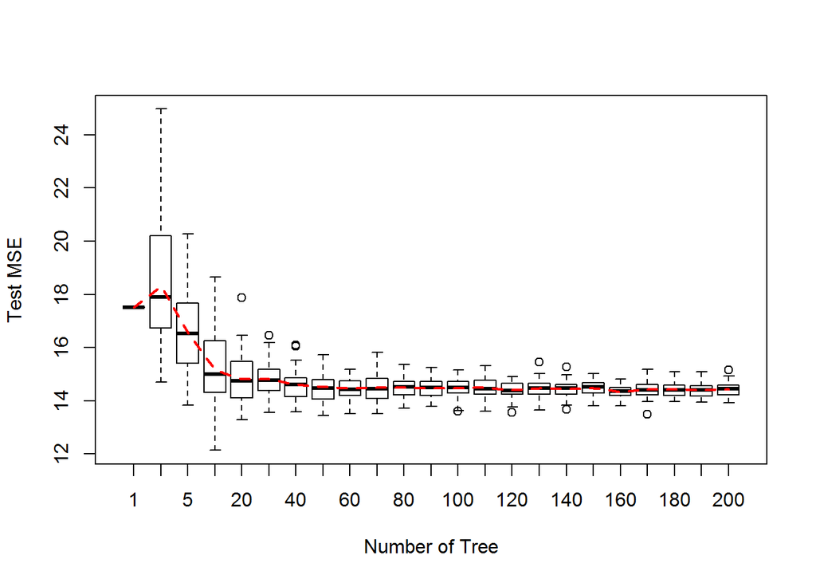

## 1.2 Out-of-bag (OOB) prediction

The out-of-bag prediction is similar to LOOCV. We use full sample. In every bootstrap, the unused sample serves as testing sample, and testing error is calculated. In the end, OOB error, root mean squared error by default, is obtained

```r
boston.bag.oob<- bagging(medv~., data = boston.train, coob=T, nbagg=100)
boston.bag.oob
```

```
##
## Bagging regression trees with 100 bootstrap replications
##
## Call: bagging.data.frame(formula = medv ~ ., data = boston.train, coob = T,
##     nbagg = 100)
##
## Out-of-bag estimate of root mean squared error:  3.789
```

## 1.3 Bagging for classification tree.

To my best knowledge, it seems that `bagging()` won’t take an argument for asymmetric loss. Therefore, the classification results might not be appropriate.

```r
credit.bag<- bagging(as.factor(default.payment.next.month)~., data = credit.train, nbagg=100)
credit.bag.pred<- predict(credit.bag, newdata = credit.train, type="prob")[,2]
credit.bag.pred.test<- predict(credit.bag, newdata = credit.test, type="prob")[,2]
library(ROCR)
```

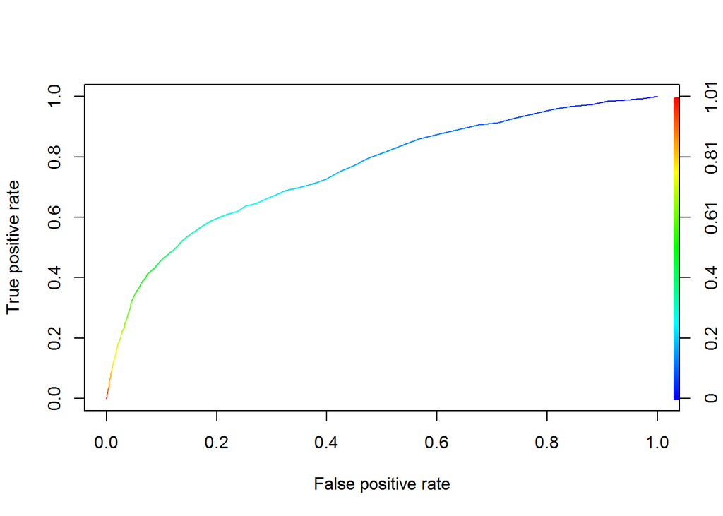

```r
pred = prediction(credit.bag.pred.test, credit.test$default.payment.next.month)
perf = performance(pred, "tpr", "fpr")
plot(perf, colorize=TRUE)
```

```r
unlist(slot(performance(pred, "auc"), "y.values"))
```

```
## [1] 0.7573542
```

The classification results are generated by specifying `type="class"`.

```r
credit.bag.pred.test<- predict(credit.bag, newdata = credit.test, type="class")
table(credit.test$default.payment.next.month, credit.bag.pred.test, dnn = c("True", "Pred"))
```

```
##     Pred
## True    0    1
##    0 3528  230
##    1  647  395
```

- Question: What will you see if you calculate the AUC of training set?

```r
predtrain = prediction(credit.bag.pred, credit.train$default.payment.next.month)
perftrain = performance(predtrain, "tpr", "fpr")
plot(perftrain, colorize=TRUE)
unlist(slot(performance(predtrain, "auc"), "y.values"))

credit.bag.pred.train <- predict(credit.bag, newdata = credit.train, type="class")
table(credit.train$default.payment.next.month, credit.bag.pred.train, dnn = c("True", "Pred"))
```

[output not shown]

Comparing with a single tree. For fair comparison, we assume the loss is symmetric.

```r
credit.rpart <- rpart(formula = default.payment.next.month ~ ., data = credit.train, method = "class")
credit.test.pred.tree1 <- predict(credit.rpart, credit.test, type="class")
table(credit.test$default.payment.next.month, credit.test.pred.tree1, dnn=c("Truth","Predicted"))
```

```
##      Predicted
## Truth    0    1
##     0 3540  218
##     1  630  412
```

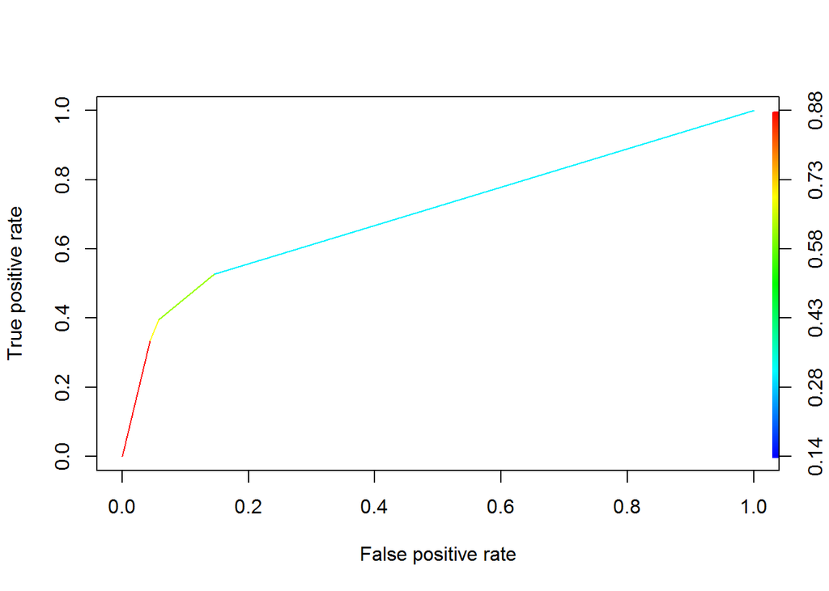

```r
credit.test.pred.tree1 <- predict(credit.rpart, credit.test, type="prob")

pred = prediction(credit.test.pred.tree1[,2], credit.test$default.payment.next.month)
perf = performance(pred, "tpr", "fpr")
plot(perf, colorize=TRUE)
```

```r
unlist(slot(performance(pred, "auc"), "y.values"))
```

```
## [1] 0.7055857
```

# 2 Random Forests

Random forest is an extension of Bagging, but it makes significant improvement in terms of prediction. The idea of random forests is to randomly select $m$ out of $p$ predictors as candidate variables for each split in each tree. Commonly, $m=\sqrt{p}$. The reason of doing this is that it can *decorrelates* the trees such that it reduces variance when we aggregate the trees. You may refer [Wikipedia](https://en.wikipedia.org/wiki/Random_forest) and the [tutorial](https://www.stat.berkeley.edu/~breiman/RandomForests/cc_home.htm) on the author’s website.

## 2.1 Random Forest for Regression

We start with Boston Housing data.

```r
library(randomForest)
boston.rf<- randomForest(medv~., data = boston.train, importance=TRUE)
boston.rf
```

```
##
## Call:
##  randomForest(formula = medv ~ ., data = boston.train, importance = TRUE)
##                Type of random forest: regression
##                      Number of trees: 500
## No. of variables tried at each split: 4
##
##           Mean of squared residuals: 11.11173
##                     % Var explained: 87.18
```

By default, $m=p/3$ for regression tree, and $m=\sqrt{p}$ for classification problem. You can change it by specifying `mtry=`. You can also specify number of trees by `ntree=`. The default is 500. The argument `importance=TRUE` allows us to see the variable imporatance.

```r
boston.rf$importance
```

```
##            %IncMSE IncNodePurity
## crim     6.3510689     1199.2948
## zn       0.9200431      392.8537
## indus    7.4991418     2214.2955
## chas     0.5385722      133.6508
## nox      5.9196108     1285.0184
## rm      42.0089196     8315.3434
## age      4.7117580      813.4378
## dis      3.5698550     1256.1236
## rad      0.8588483      199.7343
## tax      4.1535035     1057.7580
## ptratio  6.6400974     1680.2827
## black    1.3403868      491.7290
## lstat   46.8474966     6811.4455
```

The MSR is MSE of *out-of-bag* prediction (recall the OOB in bagging). The fitted randomForest actually saves all OOB errors for each `ntree` value from 1 to 500. We can make a plot to see how the OOB error changes with different `ntree`.

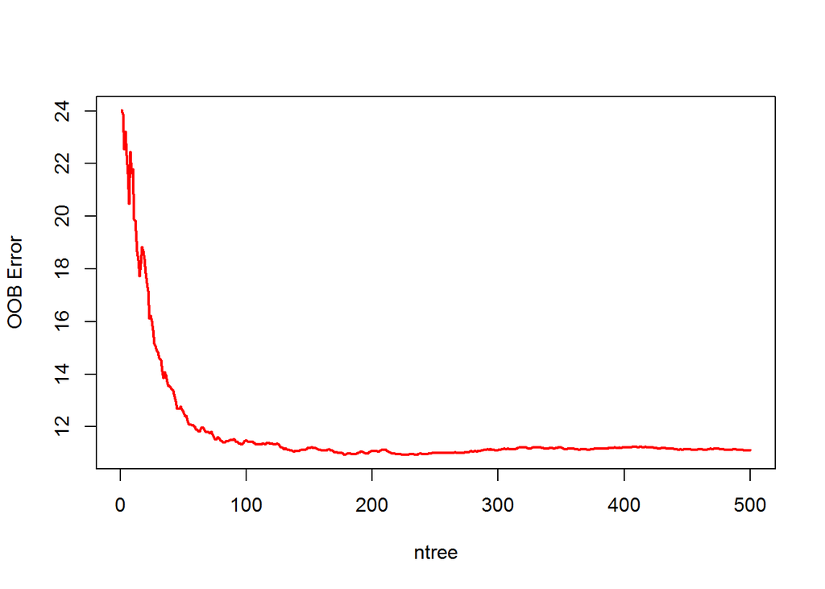

```r
plot(boston.rf$mse, type='l', col=2, lwd=2, xlab = "ntree", ylab = "OOB Error")
```

Prediction on the testing sample.

```r
boston.rf.pred<- predict(boston.rf, boston.test)
mean((boston.test$medv-boston.rf.pred)^2)
```

```
## [1] 16.26959
```

```r
oob.err<- rep(0, 13)
test.err<- rep(0, 13)
for(i in 1:13){
  fit<- randomForest(medv~., data = boston.train, mtry=i)
  oob.err[i]<- fit$mse[500]
  test.err[i]<- mean((boston.test$medv-predict(fit, boston.test))^2)
  cat(i, " ")
}
```

```
## 1  2  3  4  5  6  7  8  9  10  11  12  13
```

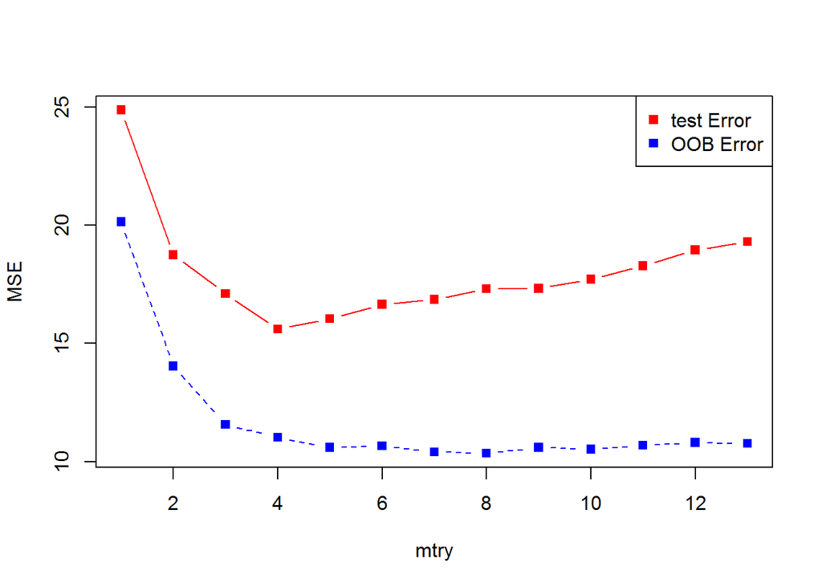

```r
matplot(cbind(test.err, oob.err), pch=15, col = c("red", "blue"), type = "b", ylab = "MSE", xlab = "mtry")
legend("topright", legend = c("test Error", "OOB Error"), pch = 15, col = c("red", "blue"))
```

#### 2.1.0.1 Exercise: Create a plot displaying the test error across `ntree=`1, …, 500, and `mtry=` 1, …, 13. (You can draw 13 lines in different color representing each $m$).

## 2.2 Random Forest for Classification

```r
credit.rf <- randomForest(as.factor(default.payment.next.month)~., data = credit.train)
credit.rf
```

```
##
## Call:
##  randomForest(formula = as.factor(default.payment.next.month) ~      ., data = credit.train)
##                Type of random forest: classification
##                      Number of trees: 500
## No. of variables tried at each split: 4
##
##         OOB estimate of  error rate: 18.39%
## Confusion matrix:
##      0   1 class.error
## 0 5306 304  0.05418895
## 1 1020 570  0.64150943
```

We can again easily plot the error rate vs. ntree. However, as far as I know, `randomForest` does not support asymmetric loss either. So it always uses the overall misclassification rate as the error.

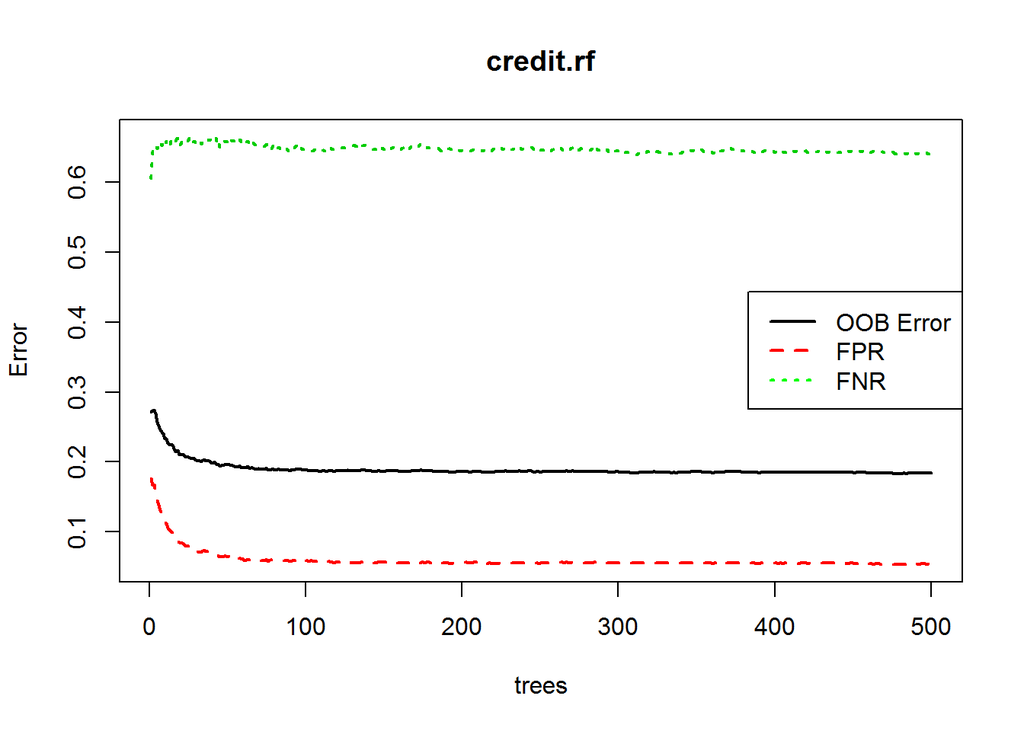

```r
plot(credit.rf, lwd=rep(2, 3))
legend("right", legend = c("OOB Error", "FPR", "FNR"), lwd=rep(2, 3), lty = c(1,2,3), col = c("black", "red", "green"))
```

As we can see, the FNR is very high, just as the confusion matrix. For prediction purpose, nevertheless, we can use `type="prob"` to get predicted probability and then find optimal cut-off. Let’s do in-sample prediction and find optimal cut-off.

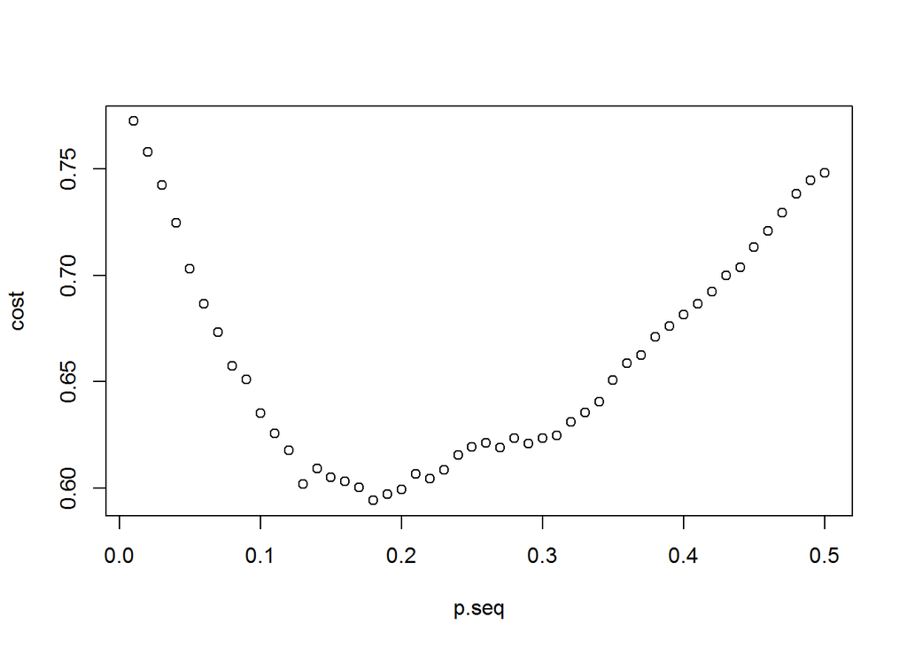

```r
credit.rf.pred<- predict(credit.rf, type = "prob")[,2]
costfunc = function(obs, pred.p, pcut){
    weight1 = 5   # define the weight for "true=1 but pred=0" (FN)
    weight0 = 1    # define the weight for "true=0 but pred=1" (FP)
    c1 = (obs==1)&(pred.p<pcut)    # count for "true=1 but pred=0"   (FN)
    c0 = (obs==0)&(pred.p>=pcut)   # count for "true=0 but pred=1"   (FP)
    cost = mean(weight1*c1 + weight0*c0)  # misclassification with weight
    return(cost) # you have to return to a value when you write R functions
}
p.seq = seq(0.01, 0.5, 0.01)
cost = rep(0, length(p.seq))
for(i in 1:length(p.seq)){
    cost[i] = costfunc(obs = credit.train$default.payment.next.month, pred.p = credit.rf.pred, pcut = p.seq[i])
}
plot(p.seq, cost)
```

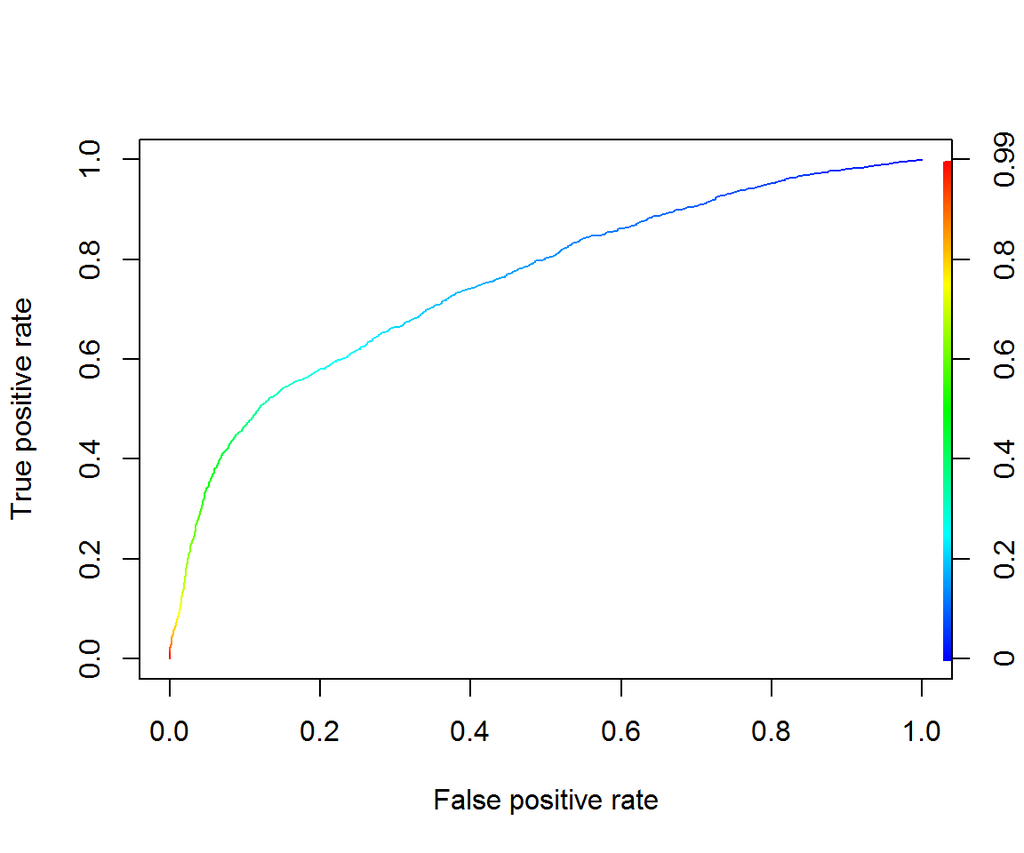

```r
library(ROCR)
pred <- prediction(credit.rf.pred, credit.train$default.payment.next.month)
perf <- performance(pred, "tpr", "fpr")
plot(perf, colorize=TRUE)
```

```r
#Get the AUC
unlist(slot(performance(pred, "auc"), "y.values"))
```

```
## [1] 0.7546905
```

Create the confusion matrix based on the optimal cutoff probability.

```r
## out-of-sample
optimal.pcut= p.seq[which(cost==min(cost))]
credit.rf.pred.test<- predict(credit.rf, newdata=credit.test, type = "prob")[,2]
credit.rf.class.test<- (credit.rf.pred.test>optimal.pcut)*1
table(credit.test$default.payment.next.month, credit.rf.class.test, dnn = c("True", "Pred"))
```

```
##     Pred
## True    0    1
##    0 2287 1471
##    1  263  779
```

# 3 Boosting

Boosting builds a number of small trees, and each time, the response is the residual from last tree. It is a sequential procedure. We use `gbm` package to build boosted trees.

## 3.1 Boosting for regression trees

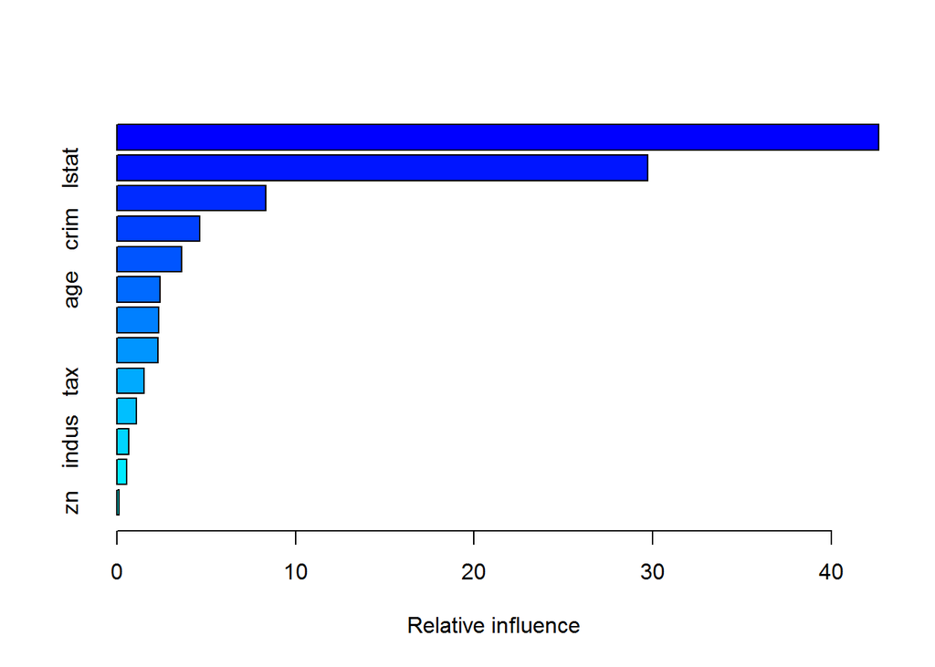

```
##             var    rel.inf
## rm           rm 42.6558276
## lstat     lstat 29.7148052
## dis         dis  8.3594467
## crim       crim  4.6257292
## nox         nox  3.6297727
## age         age  2.4313423
## ptratio ptratio  2.3278817
## black     black  2.3123676
## tax         tax  1.5340277
## chas       chas  1.0963066
## indus     indus  0.6580734
## rad         rad  0.5404433
## zn           zn  0.1139760
```

```r
library(gbm)
?gbm
boston.boost<- gbm(medv~., data = boston.train, distribution = "gaussian", n.trees = 10000, shrinkage = 0.01, interaction.depth = 8)
summary(boston.boost)
```

Note that we need to specify `distribution = "gaussian"` if we are working on regression tree. The default is *Bernoulli* distribution for binary classification problem. `n.trees` is the number of small trees we fit. We need to choose this parameter carefully because it may results in overfitting if the number is too large. `shrinkage` is another tuning parameter that controls how much contribution each tree makes. `interaction.depth` is how many splits of each tree we want. All those tuning parameters can be chosen from cross-validation. The idea is that we don’t want overfitting.

The fitted boosted tree also gives the relation between response and each predictor.

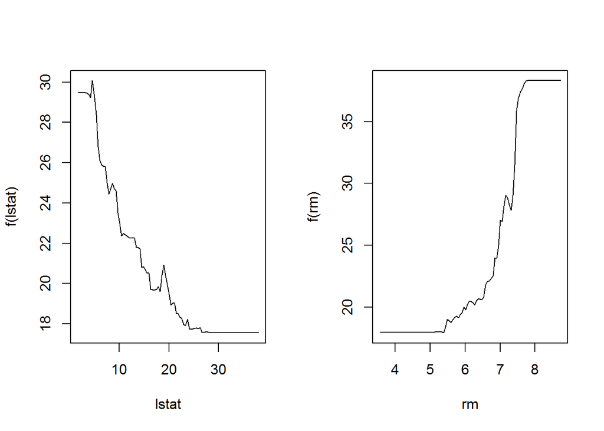

```r
par(mfrow=c(1,2))
plot(boston.boost, i="lstat")
plot(boston.boost, i="rm")
```

Prediction on testing sample.

```r
boston.boost.pred.test<- predict(boston.boost, boston.test, n.trees = 10000)
mean((boston.test$medv-boston.boost.pred.test)^2)
```

```
## [1] 15.64001
```

We can investigate how the testing error changes with different number of trees.

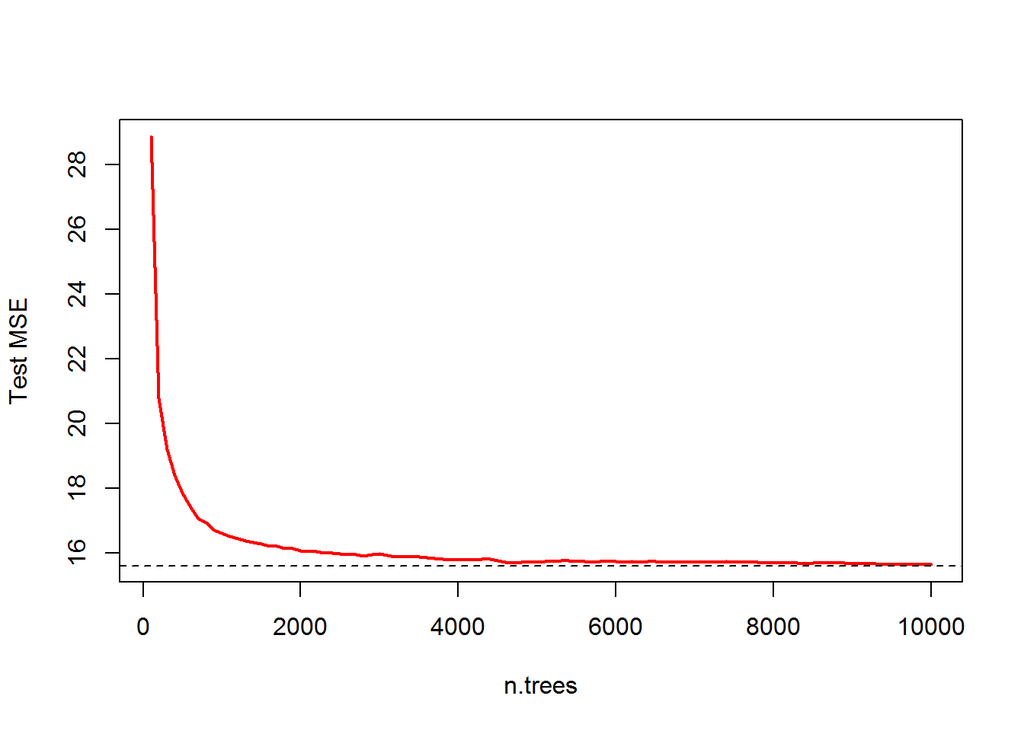

```r
ntree<- seq(100, 10000, 100)
predmat<- predict(boston.boost, newdata = boston.test, n.trees = ntree)
err<- apply((predmat-boston.test$medv)^2, 2, mean)
plot(ntree, err, type = 'l', col=2, lwd=2, xlab = "n.trees", ylab = "Test MSE")
abline(h=min(test.err), lty=2)
```

The horizontal line is the best prediction error from random forests we obtained earlier.

## 3.2 Boosting for classification trees

```r
library(adabag)
credit.train$default.payment.next.month= as.factor(credit.train$default.payment.next.month)
credit.boost= boosting(default.payment.next.month~., data = credit.train, boos = T)

# Training AUC
pred.credit.boost= predict(credit.boost, newdata = credit.train)
pred <- prediction(pred.credit.boost$prob[,2], credit.train$default.payment.next.month)
perf <- performance(pred, "tpr", "fpr")
plot(perf, colorize=TRUE)
#Get the AUC
unlist(slot(performance(pred, "auc"), "y.values"))

pred.credit.boost= predict(credit.boost, newdata = credit.test)
# Testing AUC
pred <- prediction(pred.credit.boost$prob[,2], credit.test$default.payment.next.month)
perf <- performance(pred, "tpr", "fpr")
plot(perf, colorize=TRUE)
#Get the AUC
unlist(slot(performance(pred, "auc"), "y.values"))
```

[output not shown]